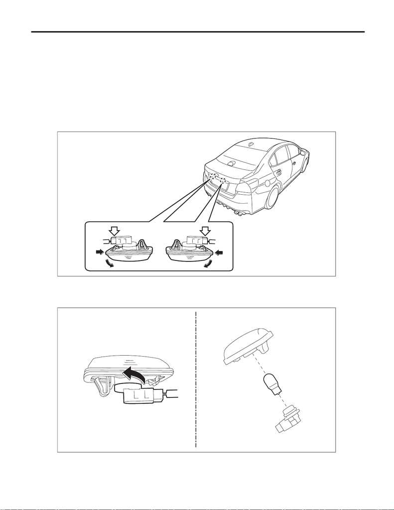

LI-56

License Plate Light

LIGHTING SYSTEM

30.License Plate Light

A: REMOVAL

1) Disconnect the ground cable from battery. <Ref. to NT-5, BATTERY, NOTE, Note.>

NOTE:

For models other than STI model, disconnect the ground terminal from battery sensor.

2) Remove the trim panel - trunk lid. <Ref. to EI-95, REMOVAL, Trunk Room Trim.>

3) Remove the garnish - trunk. <Ref. to EI-51, REMOVAL, Trunk Lid Garnish.>

4) Remove the license plate light.

(1) Release the claws and pull out the license plate light.

(2) Disconnect the connector, and remove the license plate light.

5) Rotate the bulb socket in the direction of arrow shown in the figure to remove the license plate light bulb.

CAUTION:

Use a dry clean cloth so that no grease or water adheres to the glass portion of the bulb.

LI-01730

LI-01731

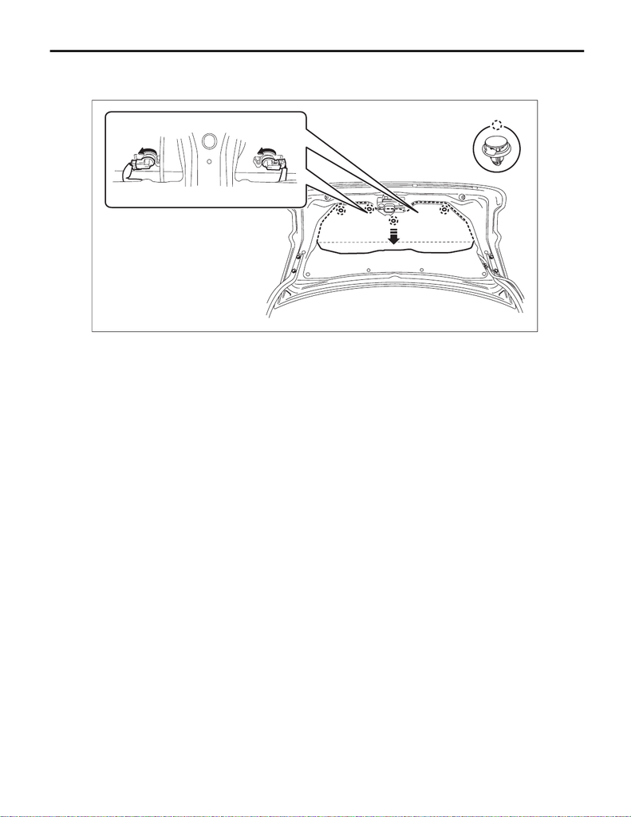

LI-57

License Plate Light

LIGHTING SYSTEM

NOTE:

B: INSTALLATION

1) Install the license plate light bulb.

CAUTION:

Use a dry clean cloth so that no grease or water adheres to the glass portion of the bulb.

2) Install the license plate light.

3) Install the garnish - trunk. <Ref. to EI-51, INSTALLATION, Trunk Lid Garnish.>

Tightening torque:

4.5 N·m (0.5 kgf-m, 3.3 ft-lb)

4) Install the trim panel - trunk lid.

5) Connect the battery ground terminal. <Ref. to NT-5, BATTERY, NOTE, Note.>

NOTE:

For models other than STI model, connect the ground terminal to battery sensor.

LI-01732